# Exploratory Data Analysis on the Washigton crime report

Vishal Fulsundar, Suraj kapare, Halima Al Balushi, Naiska Buyandalai

2024-10-28

```r
# some of common options (and the defaults) are:
# include=T, eval=T, echo=T, results='hide'/'asis'/'markup',..., collapse=F, warning=T, message=T, error=T, cache=T, fig.width=6, fig.height=4, fig.dim=c(6,4) #inches, fig.align='left'/'center','right',
knitr::opts_chunk$set(warning = F, results = "markup", message = F)
# knitr::opts_chunk$set(warning = F, results = "hide", message = F)
options(scientific=T, digits = 3)
```

# 1)Introduction—-

Introduction: In our project, we aim to investigate crime patterns in Washington, DC, utilizing data from the Open Data DC portal. The dataset, “Crime Incidents in 2023,” comprises 34,215 observations detailing reported crimes, including information on the type of offense, time of occurrence, geographic location, and methods involved. As individuals, especially students, consider buying a house, renting an apartment, relocating, or traveling, one of the first questions that arises is, “Is it safe?” This concern for safety drives many to seek out neighborhoods with low crime rates before evaluating other factors such as price, amenities, and accessibility. Therefore, understanding crime dynamics is crucial not only for law enforcement but also for residents and potential newcomers to the area. The primary focus of our analysis is to explore crime density across different areas of Washington, DC, identifying neighborhoods that experience the highest levels of criminal activity. This exploration aims to uncover patterns that can inform law enforcement resource allocation and guide community safety initiatives aimed at crime prevention. By providing insights into crime trends, we hope to empower individuals and families to make informed decisions regarding their living environments.

# 2)Data Sources:

Crime Incidents in Washington, DC (2023): Link: Crime Incidents in 2023 Description: This dataset serves as the primary source for our analysis, encompassing 34,215 reported crime incidents in Washington, DC. It includes critical information such as the type of offense, time of occurrence, geographic location, and methods involved. This comprehensive dataset is essential for examining crime patterns and densities across different neighborhoods

Our Main data frame named- Crime_data have records around 34215observation including the 25 variables. The data set(crime_data) give overiew of the potensial varibles in the dataset.These varible give /provide the details view of the each incident,enabling us to analyze across dimensions like geographical location, type of offense, time of occurrence, and associated methods as well as timing of the occurence betwnn the shift(day,evening,midnight). ex 1) Type of offence- nature of the crime, such as theft, assault, or vandalism, allowing us to categorize and compare crime types 2) Shift of occurence- shift the crime happened, which can reveal temporal patterns or peak crime times. 3)Method Involved: Provides information on any specific method or weapon(knief,gun,other) used in the offense 4)District or Area: The specific district or police jurisdiction involved,

```r
crime_data <- read.csv("C:/Users/DELL/Documents/GitHub/crime-analysis-washington-dc-2023/Crime_Incidents_in_2023.csv")
head(crime_data)
```

```
##        X      Y      CCN             REPORT_DAT    SHIFT METHOD
## 1 396736 140470 23120415 2023/07/25 05:09:14+00 MIDNIGHT OTHERS
## 2 397177 146810 23047033 2023/03/27 06:12:11+00 MIDNIGHT    GUN
## 3 398478 137857 23187303 2023/11/15 19:31:25+00      DAY OTHERS
## 4 396659 137377 23055316 2023/04/10 06:13:40+00 MIDNIGHT OTHERS
## 5 397874 139955 23056311 2023/04/11 23:18:47+00  EVENING OTHERS
## 6 400976 133256 23156424 2023/09/22 13:39:32+00      DAY OTHERS
##               OFFENSE                                                BLOCK
## 1             ROBBERY                    1600 - 1699 BLOCK OF PARK ROAD NW
## 2             ROBBERY              8129  - 8148 BLOCK OF EASTERN AVENUE NW
## 3         THEFT/OTHER                       400 - 499 BLOCK OF O STREET NW
## 4        THEFT F/AUTO                  1100 - 1129 BLOCK OF 17TH STREET NW
## 5 MOTOR VEHICLE THEFT                   700 - 999 BLOCK OF HOBART PLACE NW
## 6             ROBBERY 1900 - 1999 BLOCK OF MARTIN LUTHER KING JR AVENUE SE
##   XBLOCK YBLOCK WARD ANC DISTRICT PSA NEIGHBORHOOD_CLUSTER BLOCK_GROUP
```

[output cut: 20 more lines]

```r
str(crime_data)
```

```
## 'data.frame':    34215 obs. of  25 variables:
##  $ X                   : num  396736 397177 398478 396659 397874 ...
##  $ Y                   : num  140470 146810 137857 137377 139955 ...
##  $ CCN                 : int  23120415 23047033 23187303 23055316 23056311 23156424 23156932 23131286 23087621 23130132 ...
##  $ REPORT_DAT          : chr  "2023/07/25 05:09:14+00" "2023/03/27 06:12:11+00" "2023/11/15 19:31:25+00" "2023/04/10 06:13:40+00" ...
##  $ SHIFT               : chr  "MIDNIGHT" "MIDNIGHT" "DAY" "MIDNIGHT" ...
##  $ METHOD              : chr  "OTHERS" "GUN" "OTHERS" "OTHERS" ...
##  $ OFFENSE             : chr  "ROBBERY" "ROBBERY" "THEFT/OTHER" "THEFT F/AUTO" ...
##  $ BLOCK               : chr  "1600 - 1699 BLOCK OF PARK ROAD NW" "8129  - 8148 BLOCK OF EASTERN AVENUE NW" "400 - 499 BLOCK OF O STREET NW" "1100 - 1129 BLOCK OF 17TH STREET NW" ...
##  $ XBLOCK              : num  396736 397177 398478 396659 397874 ...
##  $ YBLOCK              : num  140470 146810 137857 137377 139955 ...
##  $ WARD                : int  1 4 2 2 1 8 6 2 2 1 ...
##  $ ANC                 : chr  "1D" "4A" "2G" "2C" ...
##  $ DISTRICT            : int  3 4 3 2 3 7 1 1 2 3 ...
##  $ PSA                 : int  302 401 308 207 304 701 103 101 209 302 ...
##  $ NEIGHBORHOOD_CLUSTER: chr  "Cluster 2" "Cluster 16" "Cluster 7" "Cluster 6" ...
##  $ BLOCK_GROUP         : chr  "002702 1" "001600 1" "004801 3" "010700 1" ...
##  $ CENSUS_TRACT        : int  2702 1600 4801 10700 3100 7503 10500 5801 10100 2702 ...
##  $ VOTING_PRECINCT     : chr  "Precinct 40" "Precinct 62" "Precinct 18" "Precinct 17" ...
##  $ LATITUDE            : num  38.9 39 38.9 38.9 38.9 ...
##  $ LONGITUDE           : num  -77 -77 -77 -77 -77 ...
##  $ BID                 : chr  "" "" "" "GOLDEN TRIANGLE" ...
##  $ START_DATE          : chr  "2023/07/25 04:10:00+00" "2023/03/27 04:38:00+00" "2023/11/06 21:25:00+00" "2023/04/10 05:50:00+00" ...
##  $ END_DATE            : chr  "2023/07/25 04:15:00+00" "" "2023/11/06 21:30:00+00" "2023/04/10 05:55:00+00" ...
##  $ OBJECTID            : int  596090380 596090385 596090386 596090387 596090388 596090389 596090390 596090393 596090394 596090395 ...
##  $ OCTO_RECORD_ID      : logi  NA NA NA NA NA NA ...
```

Neighborhood Clusters: Link: Neighborhood Clusters Description: This dataset provides a mapping of numerical identifiers for neighborhoods to more recognizable names, such as Columbia Heights, Georgetown, and Dupont Circle. By integrating this data, we enhance the interpretability of our analysis, making it easier for stakeholders to understand the geographic context of crime data.

Cluster has 46 observations and 2 variables and data frame represent neighborhood clusters in Washington, DC. NBH_NAMES: This column contains the full names of the neighborhoods within each cluster. NAME: This column contains the cluster identifier (e.g., “Cluster 16”, “Cluster 41”), which is a unique numerical label for each neighborhood cluster.

```r
library(dplyr)
cluster <- read.csv("C:/Users/DELL/Documents/GitHub/crime-analysis-washington-dc-2023/Neighborhood_Clusters.csv")

cluster <- cluster %>%  select(NAME,NBH_NAMES)
head(cluster)
```

```
##         NAME                                               NBH_NAMES
## 1 Cluster 16   Colonial Village, Shepherd Park, North Portal Estates
## 2 Cluster 41                                         Rock Creek Park
## 3 Cluster 10                   Hawthorne, Barnaby Woods, Chevy Chase
## 4 Cluster 17                          Takoma, Brightwood, Manor Park
## 5 Cluster 40                                             Walter Reed
## 6 Cluster 19 Lamont Riggs, Queens Chapel, Fort Totten, Pleasant Hill
```

```r
str(cluster)
```

```
## 'data.frame':    46 obs. of  2 variables:
##  $ NAME     : chr  "Cluster 16" "Cluster 41" "Cluster 10" "Cluster 17" ...
##  $ NBH_NAMES: chr  "Colonial Village, Shepherd Park, North Portal Estates" "Rock Creek Park" "Hawthorne, Barnaby Woods, Chevy Chase" "Takoma, Brightwood, Manor Park" ...
```

DC Police Stations: Link: DC Police Stations Description: This dataset contains the locations of police stations across Washington, DC. Incorporating this information allows us to analyze the proximity of law enforcement resources to neighborhoods with varying crime rates, offering insights into potential coverage gaps.

Dc police station data frame have dataframe has 15 observations and 23 variables, some variables for examples are Zip code , address, lattitude, longitude ,Type, name.

```r
# Reading Police Stations data
police_stations <- read.csv("C:/Users/DELL/Documents/GitHub/crime-analysis-washington-dc-2023/Police_Stations.csv")

head(police_stations)
```

```
##          X       Y                               NAME                ADDRESS
## 1 -8574652 4716392                    District 4 (4D) 6001 GEORGIA AVENUE NW
## 2 -8579932 4712344                    District 2 (2D)   3320 IDAHO AVENUE NW
## 3 -8574455 4712033              District 4 Substation       750 PARK ROAD NW
## 4 -8573445 4710532 Deaf and Hard Hearing Liaison Unit  310 MCMILLAN DRIVE NW
## 5 -8576373 4710529                Latino Liaison Unit  1800 COLUMBIA ROAD NW
## 6 -8575828 4709915                    District 3 (3D)       1620 V STREET NW
##   ZIPCODE          PHONE            FAX       TYPE             CONTACT ROOM
## 1   20011 (202) 715-7400 (202) 722-1791    Station Cmdr  Hilton Burton
## 2   20016 (202) 715-7300 (202) 364-3961    Station Cmdr  Robert J  Con
## 3   20010 (202) 576-8222 (202) 576-3350 Substation Insp  Diane Groomes
## 4   20009 (202) 671-3550                               Off Myra Jordan
## 5   20009 (202) 673-4445                             Sgt  Juan Espinal
## 6   20009 (202) 673-6815 (202) 518-0008    Station   Cmdr  Larry McCoy
##                                                             WEB_URL MAR_ID
```

[output cut: 27 more lines]

```r
str(police_stations)
```

```
## 'data.frame':    15 obs. of  23 variables:
##  $ X        : num  -8574652 -8579932 -8574455 -8573445 -8576373 ...
##  $ Y        : num  4716392 4712344 4712033 4710532 4710529 ...
##  $ NAME     : chr  "District 4 (4D)" "District 2 (2D)" "District 4 Substation" "Deaf and Hard Hearing Liaison Unit" ...
##  $ ADDRESS  : chr  "6001 GEORGIA AVENUE NW" "3320 IDAHO AVENUE NW" "750 PARK ROAD NW" "310 MCMILLAN DRIVE NW" ...
##  $ ZIPCODE  : int  20011 20016 20010 20009 20009 20009 20002 20001 20001 20019 ...
##  $ PHONE    : chr  "(202) 715-7400" "(202) 715-7300" "(202) 576-8222" "(202) 671-3550" ...
##  $ FAX      : chr  "(202) 722-1791" "(202) 364-3961" "(202) 576-3350" " " ...
##  $ TYPE     : chr  "Station" "Station" "Substation" "" ...
##  $ CONTACT  : chr  "Cmdr  Hilton Burton" "Cmdr  Robert J  Con" "Insp  Diane Groomes" "Off Myra Jordan" ...
##  $ ROOM     : chr  " " " " " " " " ...
##  $ WEB_URL  : chr  "http://mpdc.dc.gov/page/police-districts-and-police-service-areas" "http://mpdc.dc.gov/page/police-districts-and-police-service-areas" "http://mpdc.dc.gov/page/police-districts-and-police-service-areas" "http://mpdc.dc.gov/page/police-districts-and-police-service-areas" ...
##  $ MAR_ID   : int  243485 222229 233054 299642 235413 241847 286486 295093 279642 294469 ...
##  $ GIS_ID   : chr  "PolStnPt_1" "PolStnPt_2" "PolStnPt_3" "PolStnPt_4" ...
##  $ LATITUDE : num  39 38.9 38.9 38.9 38.9 ...
##  $ LONGITUDE: num  -77 -77.1 -77 -77 -77 ...
##  $ XCOORD   : num  397624 393511 397777 398564 396283 ...
##  $ YCOORD   : num  143913 140776 140532 139368 139366 ...
##  $ GLOBALID : chr  "{43654A11-0598-4578-BC47-58249EAA5278}" "{FD5B07BB-47BF-44ED-AC68-15BBBB783A38}" "{2B5C2A3F-BCB7-467A-BBBD-DAC77C28B7EF}" "{97BE2CD3-8E81-4644-9A10-22016469C041}" ...
##  $ CREATOR  : logi  NA NA NA NA NA NA ...
##  $ CREATED  : logi  NA NA NA NA NA NA ...
##  $ EDITOR   : chr  "DCGIS" "DCGIS" "DCGIS" "DCGIS" ...
##  $ EDITED   : chr  "2018/02/07 02:48:32+00" "2018/02/07 02:48:32+00" "2018/02/07 02:48:32+00" "2018/02/07 02:48:32+00" ...
##  $ OBJECTID : int  1 2 3 4 5 6 7 8 9 10 ...
```

# 2.1) Library—-

WE have loaded the required library here ggplot2: Used for creating static visualizations, such as line graphs, bar charts, and scatter plots.

dplyr: A data manipulation package that provides functions to filter, arrange, and summarize data.

lubridate: Simplifies date and time manipulation, making it easier to work with date formats, extract time components, and perform calculations.

sf: Provides support for handling spatial data, allowing you to analyze and visualize geographic data.

leaflet: Used for creating interactive maps, often integrating spatial data from the sf package.

```r
# 2) load the require library

library(ggplot2)
library(dplyr)
# ggplot library for graphs
library(lubridate) # fro thr data manupulation
library(sf)
library(leaflet)
```

# 2.2) data collection–

from the is.null operator , we got that there is no record in the OCTO_RECORD_ID column. total 34215 records are missing from the records.

```r
colnames(crime_data)
```

```
##  [1] "X"                    "Y"                    "CCN"
##  [4] "REPORT_DAT"           "SHIFT"                "METHOD"
##  [7] "OFFENSE"              "BLOCK"                "XBLOCK"
## [10] "YBLOCK"               "WARD"                 "ANC"
## [13] "DISTRICT"             "PSA"                  "NEIGHBORHOOD_CLUSTER"
## [16] "BLOCK_GROUP"          "CENSUS_TRACT"         "VOTING_PRECINCT"
## [19] "LATITUDE"             "LONGITUDE"            "BID"
## [22] "START_DATE"           "END_DATE"             "OBJECTID"
## [25] "OCTO_RECORD_ID"
```

```r
colSums(is.na(crime_data))
```

```
##                    X                    Y                  CCN
##                    0                    0                    0
##           REPORT_DAT                SHIFT               METHOD
##                    0                    0                    0
##              OFFENSE                BLOCK               XBLOCK
##                    0                    0                    0
##               YBLOCK                 WARD                  ANC
##                    0                    5                    0
##             DISTRICT                  PSA NEIGHBORHOOD_CLUSTER
##                  285                  298                    0
##          BLOCK_GROUP         CENSUS_TRACT      VOTING_PRECINCT
##                    0                   16                    0
##             LATITUDE            LONGITUDE                  BID
##                    0                    0                    0
##           START_DATE             END_DATE             OBJECTID
##                    0                    0                    0
##       OCTO_RECORD_ID
##                34215
```

```r
# Check for duplicate rows from the data set
duplicates <- crime_data[duplicated(crime_data), ]
nrow(duplicates)
```

```
## [1] 0
```

```r
head(crime_data)
```

```
##        X      Y      CCN             REPORT_DAT    SHIFT METHOD
## 1 396736 140470 23120415 2023/07/25 05:09:14+00 MIDNIGHT OTHERS
## 2 397177 146810 23047033 2023/03/27 06:12:11+00 MIDNIGHT    GUN
## 3 398478 137857 23187303 2023/11/15 19:31:25+00      DAY OTHERS
## 4 396659 137377 23055316 2023/04/10 06:13:40+00 MIDNIGHT OTHERS
## 5 397874 139955 23056311 2023/04/11 23:18:47+00  EVENING OTHERS
## 6 400976 133256 23156424 2023/09/22 13:39:32+00      DAY OTHERS
##               OFFENSE                                                BLOCK
## 1             ROBBERY                    1600 - 1699 BLOCK OF PARK ROAD NW
## 2             ROBBERY              8129  - 8148 BLOCK OF EASTERN AVENUE NW
## 3         THEFT/OTHER                       400 - 499 BLOCK OF O STREET NW
## 4        THEFT F/AUTO                  1100 - 1129 BLOCK OF 17TH STREET NW
## 5 MOTOR VEHICLE THEFT                   700 - 999 BLOCK OF HOBART PLACE NW
## 6             ROBBERY 1900 - 1999 BLOCK OF MARTIN LUTHER KING JR AVENUE SE
##   XBLOCK YBLOCK WARD ANC DISTRICT PSA NEIGHBORHOOD_CLUSTER BLOCK_GROUP
```

[output cut: 20 more lines]

```r
sum(!is.na(crime_data$PSA))          # Check rows with PSA not missing
```

```
## [1] 33917
```

```r
sum(!is.na(crime_data$CENSUS_TRACT)) # Check rows with CENSUS_TRACT not missing
```

```
## [1] 34199
```

```r
sum(!is.na(crime_data$DISTRICT))     # Check rows with DISTRICT not missing
```

```
## [1] 33930
```

```r
sum(is.na(crime_data$WARD))          # Check rows with WARD missing
```

```
## [1] 5
```

## Data Preprocessing—

To prepare the data, we performed a series of preprocessing steps including cleaning, handling missing values, and transforming data types

we have to delete these null values , we had founded null from values ward , (census_tract) (geographical region ) , district, psa (public safty areas ) To ensure the quality of our dataset, we need to remove the records with null values in the WARD, CENSUS_TRACT, DISTRICT, and PSA.

```r
crime_data1 <- crime_data[
    !is.na(crime_data$PSA) &
    !is.na(crime_data$CENSUS_TRACT) &
    !is.na(crime_data$DISTRICT)
    ,
]
nrow(crime_data1)
```

```
## [1] 33899
```

```r
# now
```

# check Null Values-

cheking the duplicate values in the dataset.

```r
# check duplicate values
# Ensure crime_data1 is a data frame
crime_data1 <- as.data.frame(crime_data1)

duplicate_crime_data <- crime_data1[duplicated(crime_data1), ]
nrow(duplicate_crime_data)
```

```
## [1] 0
```

```r
head(crime_data1)
```

```
##        X      Y      CCN             REPORT_DAT    SHIFT METHOD
## 1 396736 140470 23120415 2023/07/25 05:09:14+00 MIDNIGHT OTHERS
## 2 397177 146810 23047033 2023/03/27 06:12:11+00 MIDNIGHT    GUN
## 3 398478 137857 23187303 2023/11/15 19:31:25+00      DAY OTHERS
## 4 396659 137377 23055316 2023/04/10 06:13:40+00 MIDNIGHT OTHERS
## 5 397874 139955 23056311 2023/04/11 23:18:47+00  EVENING OTHERS
## 6 400976 133256 23156424 2023/09/22 13:39:32+00      DAY OTHERS
##               OFFENSE                                                BLOCK
## 1             ROBBERY                    1600 - 1699 BLOCK OF PARK ROAD NW
## 2             ROBBERY              8129  - 8148 BLOCK OF EASTERN AVENUE NW
## 3         THEFT/OTHER                       400 - 499 BLOCK OF O STREET NW
## 4        THEFT F/AUTO                  1100 - 1129 BLOCK OF 17TH STREET NW
## 5 MOTOR VEHICLE THEFT                   700 - 999 BLOCK OF HOBART PLACE NW
## 6             ROBBERY 1900 - 1999 BLOCK OF MARTIN LUTHER KING JR AVENUE SE
##   XBLOCK YBLOCK WARD ANC DISTRICT PSA NEIGHBORHOOD_CLUSTER BLOCK_GROUP
```

[output cut: 20 more lines]

# 2.3)Duplicate—

so we don’t have duplicate vlaues in the data set also .

now our data set is net and clean . we are ready for the data transformation . now we have to convert some rows of data in to some other formate beacuse of our need . we some time trand=sform the solumns as according to our use of that data . for more readiblity of the data set , means we have the data formate YY/mm/DD HH/MM/SS, as we want to annalyis the data as month as well as day wise , we have to extract the months and days from this formate. create the new columns Year and month from the column Report_dat. as you can see the 2 columns are newly added at the ends of the data-frame.

```r
head(crime_data1)
```

```
##        X      Y      CCN             REPORT_DAT    SHIFT METHOD
## 1 396736 140470 23120415 2023/07/25 05:09:14+00 MIDNIGHT OTHERS
## 2 397177 146810 23047033 2023/03/27 06:12:11+00 MIDNIGHT    GUN
## 3 398478 137857 23187303 2023/11/15 19:31:25+00      DAY OTHERS
## 4 396659 137377 23055316 2023/04/10 06:13:40+00 MIDNIGHT OTHERS
## 5 397874 139955 23056311 2023/04/11 23:18:47+00  EVENING OTHERS
## 6 400976 133256 23156424 2023/09/22 13:39:32+00      DAY OTHERS
##               OFFENSE                                                BLOCK
## 1             ROBBERY                    1600 - 1699 BLOCK OF PARK ROAD NW
## 2             ROBBERY              8129  - 8148 BLOCK OF EASTERN AVENUE NW
## 3         THEFT/OTHER                       400 - 499 BLOCK OF O STREET NW
## 4        THEFT F/AUTO                  1100 - 1129 BLOCK OF 17TH STREET NW
## 5 MOTOR VEHICLE THEFT                   700 - 999 BLOCK OF HOBART PLACE NW
## 6             ROBBERY 1900 - 1999 BLOCK OF MARTIN LUTHER KING JR AVENUE SE
##   XBLOCK YBLOCK WARD ANC DISTRICT PSA NEIGHBORHOOD_CLUSTER BLOCK_GROUP
```

[output cut: 20 more lines]

```r
crime_data1$REPORT_DAT <- as.Date(crime_data1$REPORT_DAT, formate="%m/%d/%Y")

# extract the year and month also for future plots

crime_data1$Year <- format(crime_data1$REPORT_DAT,"%Y")
crime_data1$Month <- format(crime_data1$REPORT_DAT,"%m")

head(crime_data1)
```

```
##        X      Y      CCN REPORT_DAT    SHIFT METHOD             OFFENSE
## 1 396736 140470 23120415 2023-07-25 MIDNIGHT OTHERS             ROBBERY
## 2 397177 146810 23047033 2023-03-27 MIDNIGHT    GUN             ROBBERY
## 3 398478 137857 23187303 2023-11-15      DAY OTHERS         THEFT/OTHER
## 4 396659 137377 23055316 2023-04-10 MIDNIGHT OTHERS        THEFT F/AUTO
## 5 397874 139955 23056311 2023-04-11  EVENING OTHERS MOTOR VEHICLE THEFT
## 6 400976 133256 23156424 2023-09-22      DAY OTHERS             ROBBERY
##                                                  BLOCK XBLOCK YBLOCK WARD ANC
## 1                    1600 - 1699 BLOCK OF PARK ROAD NW 396736 140470    1  1D
## 2              8129  - 8148 BLOCK OF EASTERN AVENUE NW 397177 146810    4  4A
## 3                       400 - 499 BLOCK OF O STREET NW 398478 137857    2  2G
## 4                  1100 - 1129 BLOCK OF 17TH STREET NW 396659 137377    2  2C
## 5                   700 - 999 BLOCK OF HOBART PLACE NW 397874 139955    1  1E
## 6 1900 - 1999 BLOCK OF MARTIN LUTHER KING JR AVENUE SE 400976 133256    8  8A
##   DISTRICT PSA NEIGHBORHOOD_CLUSTER BLOCK_GROUP CENSUS_TRACT VOTING_PRECINCT
```

[output cut: 20 more lines]

# Reframe Data frame

we can see that , 2 new columns are added at the end of the all columns. now readjust columns, add these columns in the data frame after the REPOST_DAT.

rearrange the columns and move the columns YEAR and Month after the report year .

```r
crime_data1 <- crime_data1 %>%
    select(1:which(colnames(crime_data1) == "REPORT_DAT"), Year, Month, everything())

head(crime_data1)
```

```
##        X      Y      CCN REPORT_DAT Year Month    SHIFT METHOD
## 1 396736 140470 23120415 2023-07-25 2023    07 MIDNIGHT OTHERS
## 2 397177 146810 23047033 2023-03-27 2023    03 MIDNIGHT    GUN
## 3 398478 137857 23187303 2023-11-15 2023    11      DAY OTHERS
## 4 396659 137377 23055316 2023-04-10 2023    04 MIDNIGHT OTHERS
## 5 397874 139955 23056311 2023-04-11 2023    04  EVENING OTHERS
## 6 400976 133256 23156424 2023-09-22 2023    09      DAY OTHERS
##               OFFENSE                                                BLOCK
## 1             ROBBERY                    1600 - 1699 BLOCK OF PARK ROAD NW
## 2             ROBBERY              8129  - 8148 BLOCK OF EASTERN AVENUE NW
## 3         THEFT/OTHER                       400 - 499 BLOCK OF O STREET NW
## 4        THEFT F/AUTO                  1100 - 1129 BLOCK OF 17TH STREET NW
## 5 MOTOR VEHICLE THEFT                   700 - 999 BLOCK OF HOBART PLACE NW
## 6             ROBBERY 1900 - 1999 BLOCK OF MARTIN LUTHER KING JR AVENUE SE
##   XBLOCK YBLOCK WARD ANC DISTRICT PSA NEIGHBORHOOD_CLUSTER BLOCK_GROUP
```

[output cut: 20 more lines]

```r
str(crime_data1)
```

```
## 'data.frame':    33899 obs. of  27 variables:
##  $ X                   : num  396736 397177 398478 396659 397874 ...
##  $ Y                   : num  140470 146810 137857 137377 139955 ...
##  $ CCN                 : int  23120415 23047033 23187303 23055316 23056311 23156424 23156932 23131286 23087621 23130132 ...
##  $ REPORT_DAT          : Date, format: "2023-07-25" "2023-03-27" ...
##  $ Year                : chr  "2023" "2023" "2023" "2023" ...
##  $ Month               : chr  "07" "03" "11" "04" ...
##  $ SHIFT               : chr  "MIDNIGHT" "MIDNIGHT" "DAY" "MIDNIGHT" ...
##  $ METHOD              : chr  "OTHERS" "GUN" "OTHERS" "OTHERS" ...
##  $ OFFENSE             : chr  "ROBBERY" "ROBBERY" "THEFT/OTHER" "THEFT F/AUTO" ...
##  $ BLOCK               : chr  "1600 - 1699 BLOCK OF PARK ROAD NW" "8129  - 8148 BLOCK OF EASTERN AVENUE NW" "400 - 499 BLOCK OF O STREET NW" "1100 - 1129 BLOCK OF 17TH STREET NW" ...
##  $ XBLOCK              : num  396736 397177 398478 396659 397874 ...
##  $ YBLOCK              : num  140470 146810 137857 137377 139955 ...
##  $ WARD                : int  1 4 2 2 1 8 6 2 2 1 ...
##  $ ANC                 : chr  "1D" "4A" "2G" "2C" ...
##  $ DISTRICT            : int  3 4 3 2 3 7 1 1 2 3 ...
##  $ PSA                 : int  302 401 308 207 304 701 103 101 209 302 ...
##  $ NEIGHBORHOOD_CLUSTER: chr  "Cluster 2" "Cluster 16" "Cluster 7" "Cluster 6" ...
##  $ BLOCK_GROUP         : chr  "002702 1" "001600 1" "004801 3" "010700 1" ...
##  $ CENSUS_TRACT        : int  2702 1600 4801 10700 3100 7503 10500 5801 10100 2702 ...
##  $ VOTING_PRECINCT     : chr  "Precinct 40" "Precinct 62" "Precinct 18" "Precinct 17" ...
##  $ LATITUDE            : num  38.9 39 38.9 38.9 38.9 ...
##  $ LONGITUDE           : num  -77 -77 -77 -77 -77 ...
##  $ BID                 : chr  "" "" "" "GOLDEN TRIANGLE" ...
##  $ START_DATE          : chr  "2023/07/25 04:10:00+00" "2023/03/27 04:38:00+00" "2023/11/06 21:25:00+00" "2023/04/10 05:50:00+00" ...
##  $ END_DATE            : chr  "2023/07/25 04:15:00+00" "" "2023/11/06 21:30:00+00" "2023/04/10 05:55:00+00" ...
##  $ OBJECTID            : int  596090380 596090385 596090386 596090387 596090388 596090389 596090390 596090393 596090394 596090395 ...
##  $ OCTO_RECORD_ID      : logi  NA NA NA NA NA NA ...
```

#Normalization(Optional): first thing, for the eda part stastical test, we don;t require normalization prcosess. If we want to make a model on the dataset then pnly we have to do normalzition.

now we have to normalize the data set Beacuse ———- 1) uniformality across the featurre- in the data set we have geo location data , date time data ,character data (shift ), numerical data(disctrict ) some pincode , so our data have SACLE are drastically different , if we don;t normalize , some time anlalysis will affect

2. it will help in the improving the speed in analysis
3. avoid the feature domination effect some feature are x, y co ordinate values are greater than the ward number , so to avioid these domination we have to noramzalise the data set .

```r
# select the columns , on whcih we have to process the normalize the data.
# libriry "dplyr" require for the normalize the data .
# Select numerical columns that need to be normalized
# Exclude categorical columns like OFFENSE, SHIFT, METHOD, etc.
# Select only numeric columns that should be normalized
numeric_columns <- crime_data1 %>%
  select(X, Y, XBLOCK, YBLOCK, LATITUDE, LONGITUDE)
# Apply Min-Max normalization for each numeric column
normalize <- function(x) {
  return((x - min(x)) / (max(x) - min(x)))
}

# Apply normalization to the numeric columns
normalized_numeric_columns <- as.data.frame(lapply(numeric_columns, normalize))

# Add back the non-numeric columns to the normalized dataset
crime_data2 <- bind_cols(crime_data1 %>% select(-X, -Y, -XBLOCK, -YBLOCK, -LATITUDE, -LONGITUDE),
                          normalized_numeric_columns)

str(crime_data2)
```

```
## 'data.frame':    33899 obs. of  27 variables:
##  $ CCN                 : int  23120415 23047033 23187303 23055316 23056311 23156424 23156932 23131286 23087621 23130132 ...
##  $ REPORT_DAT          : Date, format: "2023-07-25" "2023-03-27" ...
##  $ Year                : chr  "2023" "2023" "2023" "2023" ...
##  $ Month               : chr  "07" "03" "11" "04" ...
##  $ SHIFT               : chr  "MIDNIGHT" "MIDNIGHT" "DAY" "MIDNIGHT" ...
##  $ METHOD              : chr  "OTHERS" "GUN" "OTHERS" "OTHERS" ...
##  $ OFFENSE             : chr  "ROBBERY" "ROBBERY" "THEFT/OTHER" "THEFT F/AUTO" ...
##  $ BLOCK               : chr  "1600 - 1699 BLOCK OF PARK ROAD NW" "8129  - 8148 BLOCK OF EASTERN AVENUE NW" "400 - 499 BLOCK OF O STREET NW" "1100 - 1129 BLOCK OF 17TH STREET NW" ...
##  $ WARD                : int  1 4 2 2 1 8 6 2 2 1 ...
##  $ ANC                 : chr  "1D" "4A" "2G" "2C" ...
##  $ DISTRICT            : int  3 4 3 2 3 7 1 1 2 3 ...
##  $ PSA                 : int  302 401 308 207 304 701 103 101 209 302 ...
##  $ NEIGHBORHOOD_CLUSTER: chr  "Cluster 2" "Cluster 16" "Cluster 7" "Cluster 6" ...
##  $ BLOCK_GROUP         : chr  "002702 1" "001600 1" "004801 3" "010700 1" ...
##  $ CENSUS_TRACT        : int  2702 1600 4801 10700 3100 7503 10500 5801 10100 2702 ...
##  $ VOTING_PRECINCT     : chr  "Precinct 40" "Precinct 62" "Precinct 18" "Precinct 17" ...
##  $ BID                 : chr  "" "" "" "GOLDEN TRIANGLE" ...
##  $ START_DATE          : chr  "2023/07/25 04:10:00+00" "2023/03/27 04:38:00+00" "2023/11/06 21:25:00+00" "2023/04/10 05:50:00+00" ...
##  $ END_DATE            : chr  "2023/07/25 04:15:00+00" "" "2023/11/06 21:30:00+00" "2023/04/10 05:55:00+00" ...
##  $ OBJECTID            : int  596090380 596090385 596090386 596090387 596090388 596090389 596090390 596090393 596090394 596090395 ...
##  $ OCTO_RECORD_ID      : logi  NA NA NA NA NA NA ...
##  $ X                   : num  0.369 0.394 0.468 0.365 0.434 ...
##  $ Y                   : num  0.656 0.976 0.525 0.501 0.631 ...
##  $ XBLOCK              : num  0.369 0.394 0.468 0.365 0.434 ...
##  $ YBLOCK              : num  0.656 0.976 0.525 0.501 0.631 ...
##  $ LATITUDE            : num  0.656 0.976 0.525 0.501 0.631 ...
##  $ LONGITUDE           : num  0.369 0.394 0.468 0.365 0.434 ...
```

```r
# view the first 5 rows of the data set
head(crime_data2)
```

```
##        CCN REPORT_DAT Year Month    SHIFT METHOD             OFFENSE
## 1 23120415 2023-07-25 2023    07 MIDNIGHT OTHERS             ROBBERY
## 2 23047033 2023-03-27 2023    03 MIDNIGHT    GUN             ROBBERY
## 3 23187303 2023-11-15 2023    11      DAY OTHERS         THEFT/OTHER
## 4 23055316 2023-04-10 2023    04 MIDNIGHT OTHERS        THEFT F/AUTO
## 5 23056311 2023-04-11 2023    04  EVENING OTHERS MOTOR VEHICLE THEFT
## 6 23156424 2023-09-22 2023    09      DAY OTHERS             ROBBERY
##                                                  BLOCK WARD ANC DISTRICT PSA
## 1                    1600 - 1699 BLOCK OF PARK ROAD NW    1  1D        3 302
## 2              8129  - 8148 BLOCK OF EASTERN AVENUE NW    4  4A        4 401
## 3                       400 - 499 BLOCK OF O STREET NW    2  2G        3 308
## 4                  1100 - 1129 BLOCK OF 17TH STREET NW    2  2C        2 207
## 5                   700 - 999 BLOCK OF HOBART PLACE NW    1  1E        3 304
## 6 1900 - 1999 BLOCK OF MARTIN LUTHER KING JR AVENUE SE    8  8A        7 701
##   NEIGHBORHOOD_CLUSTER BLOCK_GROUP CENSUS_TRACT VOTING_PRECINCT             BID
```

[output cut: 20 more lines]

# 3) Summary Stastics–

we examined the structure of the normalized dataset and viewed the first five rows to ensure everything was in order. This normalization step will significantly enhance the quality and reliability of our analysis moving forward.

Now start the EDA- Exploratory Data Analysis

summary stastics—– In this section, we present the summary statistics of the dataset, which provide an overview of the key characteristics of the data.

```r
crime_data2 <- crime_data2 %>%
  left_join(cluster, by = c("NEIGHBORHOOD_CLUSTER" = "NAME"))
summary(crime_data2)
```

```
##       CCN             REPORT_DAT             Year              Month
##  Min.   : 5008224   Min.   :2023-01-01   Length:33899       Length:33899
##  1st Qu.:23060406   1st Qu.:2023-04-11   Class :character   Class :character
##  Median :23116791   Median :2023-07-08   Mode  :character   Mode  :character
##  Mean   :23130983   Mean   :2023-07-04
##  3rd Qu.:23172424   3rd Qu.:2023-09-30
##  Max.   :92251156   Max.   :2024-01-01
##     SHIFT              METHOD            OFFENSE             BLOCK
##  Length:33899       Length:33899       Length:33899       Length:33899
##  Class :character   Class :character   Class :character   Class :character
##  Mode  :character   Mode  :character   Mode  :character   Mode  :character
##
##
##
##       WARD          ANC               DISTRICT         PSA
##  Min.   :1.00   Length:33899       Min.   :1.00   Min.   :101
##  1st Qu.:2.00   Class :character   1st Qu.:2.00   1st Qu.:208
##  Median :5.00   Mode  :character   Median :4.00   Median :401
##  Mean   :4.42                      Mean   :3.75   Mean   :380
##  3rd Qu.:6.00                      3rd Qu.:5.00   3rd Qu.:506
##  Max.   :8.00                      Max.   :7.00   Max.   :708
##  NEIGHBORHOOD_CLUSTER BLOCK_GROUP         CENSUS_TRACT    VOTING_PRECINCT
##  Length:33899         Length:33899       Min.   :   101   Length:33899
##  Class :character     Class :character   1st Qu.:  3701   Class :character
##  Mode  :character     Mode  :character   Median :  7202   Mode  :character
##                                          Mean   :  7672
##                                          3rd Qu.:  9102
##                                          Max.   :980000
##      BID             START_DATE          END_DATE            OBJECTID
##  Length:33899       Length:33899       Length:33899       Min.   :5.96e+08
##  Class :character   Class :character   Class :character   1st Qu.:5.96e+08
##  Mode  :character   Mode  :character   Mode  :character   Median :5.96e+08
##                                                           Mean   :5.96e+08
##                                                           3rd Qu.:5.97e+08
##                                                           Max.   :5.97e+08
##  OCTO_RECORD_ID       X               Y             XBLOCK          YBLOCK
##  Mode:logical   Min.   :0.000   Min.   :0.000   Min.   :0.000   Min.   :0.000
##  NA's:33899     1st Qu.:0.399   1st Qu.:0.437   1st Qu.:0.399   1st Qu.:0.437
##                 Median :0.502   Median :0.524   Median :0.502   Median :0.524
##                 Mean   :0.515   Mean   :0.519   Mean   :0.515   Mean   :0.519
##                 3rd Qu.:0.620   3rd Qu.:0.619   3rd Qu.:0.620   3rd Qu.:0.619
##                 Max.   :1.000   Max.   :1.000   Max.   :1.000   Max.   :1.000
##     LATITUDE       LONGITUDE      NBH_NAMES
##  Min.   :0.000   Min.   :0.000   Length:33899
##  1st Qu.:0.437   1st Qu.:0.399   Class :character
##  Median :0.524   Median :0.502   Mode  :character
##  Mean   :0.519   Mean   :0.515
##  3rd Qu.:0.619   3rd Qu.:0.620
##  Max.   :1.000   Max.   :1.000
```

# 3.1)key observation.

1. report date- show the range of the date, when 1st offence dtae started to the last date of the offence date. even report date information is avaible in the quater wise.
2. most of the varibles are catogica like ward, shift, block, methods. in the next, part we will convert some of the variable into int value.

now we will check with the count(summanry) wise variable.

```r
# Summarize total offenses by ward
offense_total_by_ward <- crime_data2 %>%
  group_by(WARD) %>%
  summarise(Total_Offenses = n())

# View the summarized data
print(offense_total_by_ward)
```

```
## # A tibble: 8 × 2
##    WARD Total_Offenses
##   <int>          <int>
## 1     1           5200
## 2     2           5418
## 3     3           2046
## 4     4           3104
## 5     5           5569
## 6     6           4252
## 7     7           4525
## 8     8           3785
```

# 3.2)Ward wise total offence–

first we have to know , what type of theft it is normally happening in DC. for refernce 1) Theft F/Auto (Theft from Auto)— #This type of theft refers to property stolen from a vehicle. It typically includes items such as: Personal belongings (e.g., bags, electronics, and clothing) 2) Motor vehicle theft refers to the unlawful taking or stealing of a vehicle itself. This includes:Cars, trucks, motorcycles, and other motor vehicles

3. Theft/Other–This category encompasses various types of thefts that do not fit into the more specific categories. It may include:– item lifting from retail stores, Theft of items from homes
4. Arson—- is the criminal act of deliberately setting fire to property. It can involve burning buildings, vehicles, or other structures

```r
offence_count <- crime_data2 %>%
  group_by(OFFENSE)%>%
  summarise(count=n())

print(offence_count)
```

```
## # A tibble: 9 × 2
##   OFFENSE                    count
##   <chr>                      <int>
## 1 ARSON                         11
## 2 ASSAULT W/DANGEROUS WEAPON  1392
## 3 BURGLARY                    1079
## 4 HOMICIDE                     274
## 5 MOTOR VEHICLE THEFT         6736
## 6 ROBBERY                     3450
## 7 SEX ABUSE                    189
## 8 THEFT F/AUTO                7690
## 9 THEFT/OTHER                13078
```

# 3.3) Offence_type Vs count–

The numbers indicate that Theft from Auto and Motor Vehicle Theft are significant issues, highlighting the importance of vehicle security. and least with the Arson type of the offence.

now we are looking the offence by the shift wise with the count wise. mean we will know in which shift most of the offence happen, by which method as well as , which type of the offence. so that we can micro - analyze these things.

EVENING (13148)— count here is the highest among the three shifts, indicating that more offenses happen during this time. Understanding the distribution of crimes by shift can help in analyzing crime trends and identifying times when specific types of crimes are more prevalent, allowing for targeted interventions

```r
# Group by SHIFT and summarize the count of offenses
offence_by_shift <- crime_data2 %>%
  group_by(SHIFT) %>%
  summarise(Count = n(), .groups = 'drop')
# Check the structure of the resulting table
#str(offence_by_shift)
# Print the summary table
print(offence_by_shift)
```

```
## # A tibble: 3 × 2
##   SHIFT    Count
##   <chr>    <int>
## 1 DAY      12961
## 2 EVENING  13148
## 3 MIDNIGHT  7790
```

# 3.4)crime count by shift

count by method – Least Common Offenses— The offenses with the lowest counts include various types of arson and sex abuse, predominantly occurring during the midnight and day shifts. Notably, arson incidents are quite rare, especially during evening and midnight hours. Highest Common Offenses: Conversely, theft-related offenses dominate the statistics, particularly the “THEFT/OTHER” category, with significant occurrences in both the evening and daytime shifts. This indicates that theft crimes are more prevalent, especially during peak hours when more people are likely to be out.

```r
# Check if SHIFT is a factor or convert it to one if needed
crime_data2$SHIFT <- as.factor(crime_data2$SHIFT)

library(dplyr)

# Ensure SHIFT is a factor
crime_data2$SHIFT <- as.factor(crime_data2$SHIFT)

offence_by_shift <- crime_data2 %>%
  group_by(SHIFT, OFFENSE) %>%
  summarise(Count = n(), .groups = 'drop') %>%
  arrange(desc(Count))

# Check the structure of the resulting data frame
#str(offence_by_shift)
#head(offence_by_shift)
# Print the summary table
print(offence_by_shift)
```

```
## # A tibble: 25 × 3
##    SHIFT    OFFENSE             Count
##    <fct>    <chr>               <int>
##  1 EVENING  THEFT/OTHER          5616
##  2 DAY      THEFT/OTHER          5433
##  3 DAY      THEFT F/AUTO         3352
##  4 EVENING  THEFT F/AUTO         2926
##  5 DAY      MOTOR VEHICLE THEFT  2752
##  6 EVENING  MOTOR VEHICLE THEFT  2529
##  7 MIDNIGHT THEFT/OTHER          2029
##  8 MIDNIGHT ROBBERY              1619
##  9 MIDNIGHT MOTOR VEHICLE THEFT  1455
## 10 MIDNIGHT THEFT F/AUTO         1412
## # ℹ 15 more rows
```

# 3.4) District Vs Count—-

District 3 has the highest total count of offenses with 6612 incidents, indicating it may have higher crime activity or reporting in comparison to others. District 7 shows the lowest total count at 2883

```r
# Summarize the count of offenses by district
OFFENCE_BY_DISTRICT <- crime_data2 %>%
  group_by(DISTRICT) %>%
  summarise(count = n(), .groups = 'drop')  # 'drop' will ungroup after summarizing
# Print the summarized table
print(OFFENCE_BY_DISTRICT)
```

```
## # A tibble: 7 × 2
##   DISTRICT count
##      <int> <int>
## 1        1  4533
## 2        2  5596
## 3        3  6612
## 4        4  4341
## 5        5  5605
## 6        6  4329
## 7        7  2883
```

As we know most of the varibles are catagorical - analyze the correlation between categorical columns in dataset, we can use various methods since correlation typically applies to numerical data. But the numerical data we have like longitude and lattitude , as well as CNN, Report date , but we don;t require numerical data coraltion of this varible.

# 4)EDA–

# 4.1)crime count by shift….

exploratory data analysis.

for eda part we are going to use the library ggplot,dyplr,tidyr,ggplot2. as we can see, the shift VS shift . evening have slighty high count of offence than day.

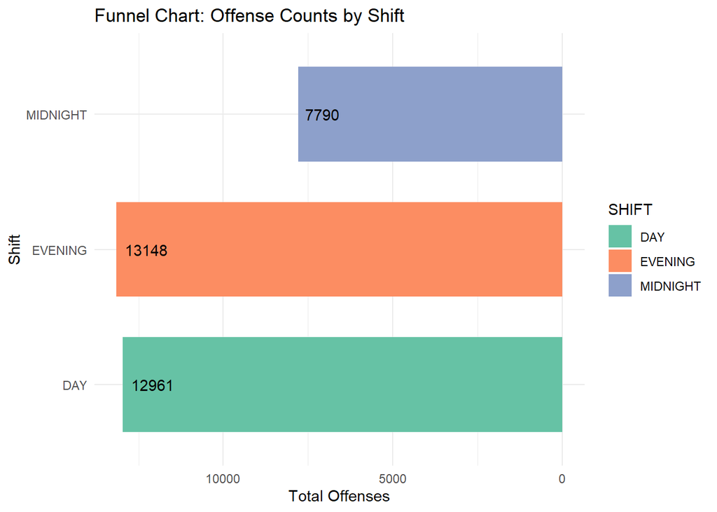

```r
# Crime count based on Shift
library(ggplot2)

offense_by_shift_funnel <- crime_data2 %>%
  group_by(SHIFT) %>%
  summarise(Total_Offenses = n(), .groups = 'drop') %>%
  arrange(desc(Total_Offenses))  # Arrange shifts by number of offenses

# Create funnel chart
ggplot(offense_by_shift_funnel, aes(x = SHIFT, y = Total_Offenses, fill = SHIFT)) +
  geom_col(width = 0.7) +  # Bar chart with narrow bars
  coord_flip() +  # Flip to make it look like a funnel
  geom_text(aes(label = Total_Offenses), hjust = -0.2) +  # Add labels
  scale_y_reverse() +  # Reverse the y-axis to give the funnel effect
  labs(title = "Funnel Chart: Offense Counts by Shift", x = "Shift", y = "Total Offenses") +
  theme_minimal() +
  scale_fill_brewer(palette = "Set2")
```

# 4.2) Distrubution of crime offense

distrubution of the crime offence by type of the offence

horizontal - bar plot for the offec frequency. cord flip for more readibility of the plot , plot is not good readable as verticle so flip to horizontal.

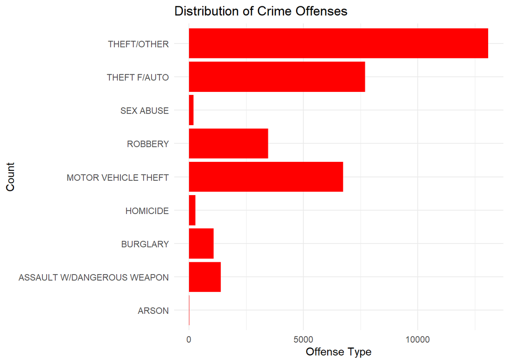

```r
ggplot(crime_data2, aes(x = OFFENSE)) +
  geom_bar(fill = "red") +
  labs(title = "Distribution of Crime Offenses", x = "Count", y = "Offense Type") +
  theme(axis.text.y = element_text(size = 100)) +
  theme_minimal()  +
 coord_flip()
```

so the most common offence is Theft/other , followed by theft/auto —

most offense type in the Washigton D.C is theft , the 1st other and on 2nd is vhehicle